# ggplot2 practise work

Rita.U.Kayitana

2026-11-02

# GGPLOT2 PRACTICE SCRIPT

# 1. Load the required library

install.packages(“ggplot2”)

library(ggplot2)

load the dataset(used a built-in)

```r
data(mtcars)
names(mtcars)
```

```
##  [1] "mpg"  "cyl"  "disp" "hp"   "drat" "wt"   "qsec" "vs"   "am"   "gear"
## [11] "carb"
```

# 2. Histogram (geom_histogram) - Shows distribution of a single number variable

It tells you how common different fuel efficiencies are. For example, you can see which MPG ranges have the most cars and whether the data is clustered or spread out.

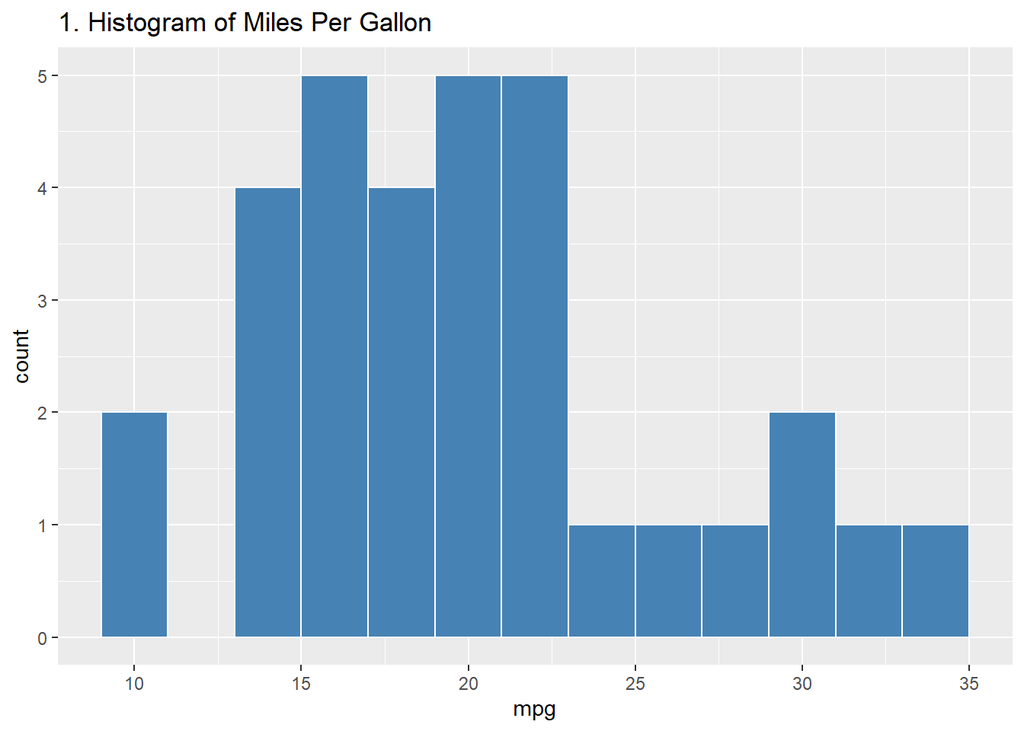

```r
library(ggplot2)
ggplot(mtcars, aes(x = mpg)) +
  geom_histogram(binwidth = 2, fill = "steelblue", color = "white") +
  labs(title = "1. Histogram of Miles Per Gallon")
```

# 3. Bar Chart (geom_bar) - Counts frequencies of a category

```r
table(mtcars$cyl)   #ilustrating individual counts in each cylinder
```

```
##
##  4  6  8
## 11  7 14
```

now graphically

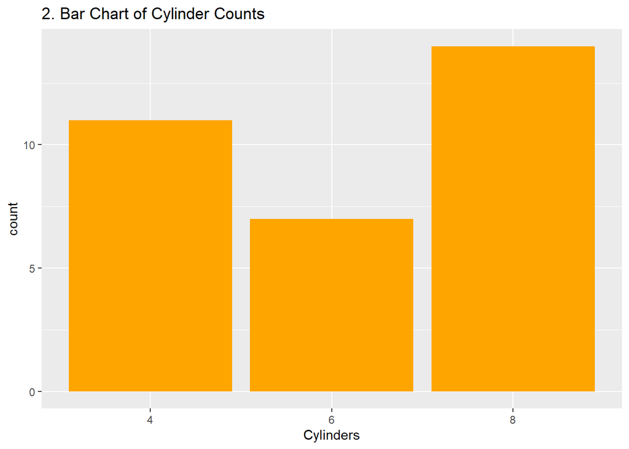

```r
ggplot(mtcars, aes(x = factor(cyl))) +
  geom_bar(fill = "orange") +
  labs(title = "2. Bar Chart of Cylinder Counts", x = "Cylinders")
```

# 4. Boxplot (geom_boxplot) - Compares numerical spread across categories.

shows the median, spread (quartiles), and potential outliers of MPG broken down by each cylinder group. For instance, you can easily see that cars with fewer cylinders tend to have a higher median MPG than cars with more cylinders.

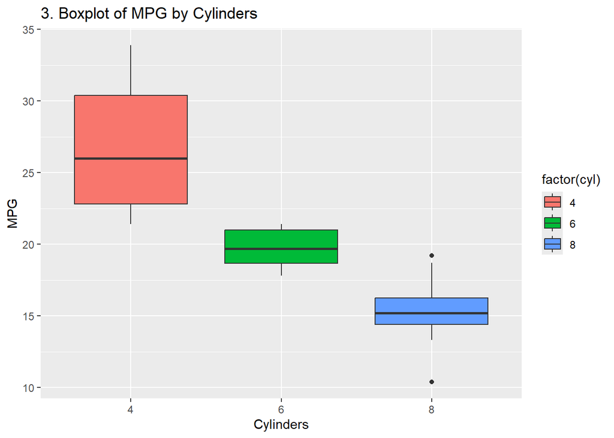

```r
ggplot(mtcars, aes(x = factor(cyl), y = mpg, fill = factor(cyl))) +
  geom_boxplot() +
  labs(title = "3. Boxplot of MPG by Cylinders", x = "Cylinders", y = "MPG")
```

# 5. Density Plot (geom_density) - Smooth distribution curve

Smooth, flowing colored curves representing the probability distribution of MPG across cylinder types. it shows where the data values are concentrated.

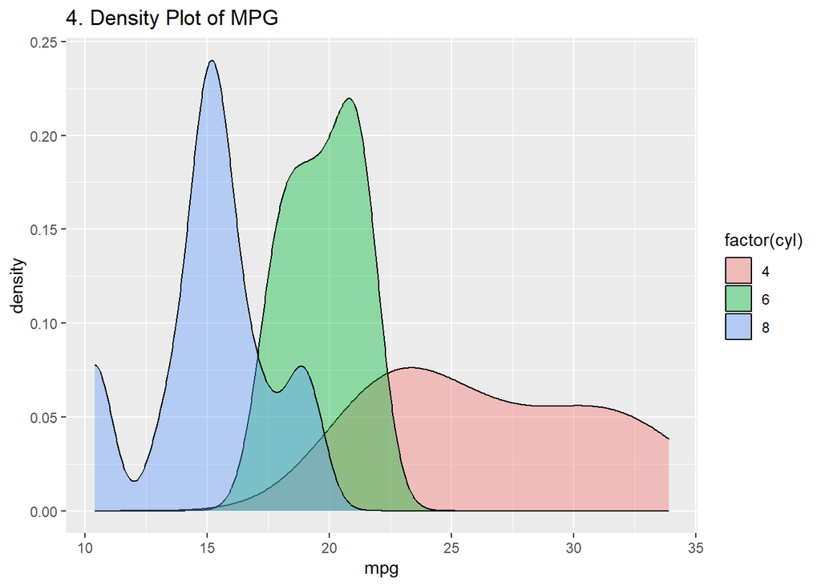

```r
ggplot(mtcars, aes(x = mpg, fill = factor(cyl))) +
  geom_density(alpha = 0.4) +
  labs(title = "4. Density Plot of MPG")
```

# 6. Scatter Plot / Points (geom_point) - Relationship between two numbers you can see a negative relationship as the weight of the car increases, the miles per gallon (fuel efficiency) goes down.

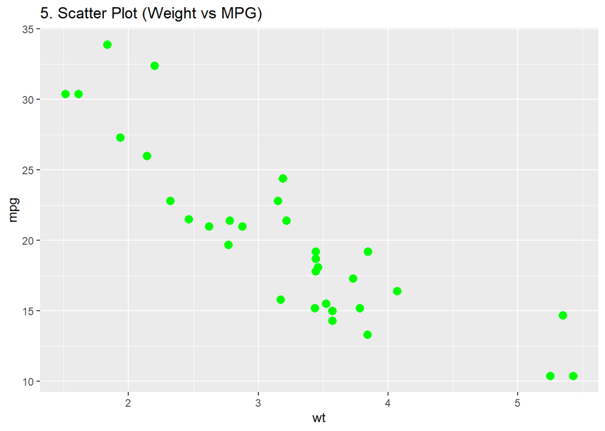

```r
ggplot(mtcars, aes(x = wt, y = mpg)) +
  geom_point(color = "green", size = 3) +
  labs(title = "5. Scatter Plot (Weight vs MPG)")
```

# 8. Line Plot (geom_line) - Connects points (useful for trends)

```r
mtcars_sorted <- mtcars[order(mtcars$wt), ]  # Sort data by weight first
mtcars_sorted
```

```
##                      mpg cyl  disp  hp drat    wt  qsec vs am gear carb
## Lotus Europa        30.4   4  95.1 113 3.77 1.513 16.90  1  1    5    2
## Honda Civic         30.4   4  75.7  52 4.93 1.615 18.52  1  1    4    2
## Toyota Corolla      33.9   4  71.1  65 4.22 1.835 19.90  1  1    4    1
## Fiat X1-9           27.3   4  79.0  66 4.08 1.935 18.90  1  1    4    1
## Porsche 914-2       26.0   4 120.3  91 4.43 2.140 16.70  0  1    5    2
## Fiat 128            32.4   4  78.7  66 4.08 2.200 19.47  1  1    4    1
## Datsun 710          22.8   4 108.0  93 3.85 2.320 18.61  1  1    4    1
## Toyota Corona       21.5   4 120.1  97 3.70 2.465 20.01  1  0    3    1
## Mazda RX4           21.0   6 160.0 110 3.90 2.620 16.46  0  1    4    4
## Ferrari Dino        19.7   6 145.0 175 3.62 2.770 15.50  0  1    5    6
## Volvo 142E          21.4   4 121.0 109 4.11 2.780 18.60  1  1    4    2
## Mazda RX4 Wag       21.0   6 160.0 110 3.90 2.875 17.02  0  1    4    4
## Merc 230            22.8   4 140.8  95 3.92 3.150 22.90  1  0    4    2
## Ford Pantera L      15.8   8 351.0 264 4.22 3.170 14.50  0  1    5    4
## Merc 240D           24.4   4 146.7  62 3.69 3.190 20.00  1  0    4    2
## Hornet 4 Drive      21.4   6 258.0 110 3.08 3.215 19.44  1  0    3    1
## AMC Javelin         15.2   8 304.0 150 3.15 3.435 17.30  0  0    3    2
## Hornet Sportabout   18.7   8 360.0 175 3.15 3.440 17.02  0  0    3    2
## Merc 280            19.2   6 167.6 123 3.92 3.440 18.30  1  0    4    4
## Merc 280C           17.8   6 167.6 123 3.92 3.440 18.90  1  0    4    4
## Valiant             18.1   6 225.0 105 2.76 3.460 20.22  1  0    3    1
## Dodge Challenger    15.5   8 318.0 150 2.76 3.520 16.87  0  0    3    2
## Duster 360          14.3   8 360.0 245 3.21 3.570 15.84  0  0    3    4
## Maserati Bora       15.0   8 301.0 335 3.54 3.570 14.60  0  1    5    8
## Merc 450SL          17.3   8 275.8 180 3.07 3.730 17.60  0  0    3    3
## Merc 450SLC         15.2   8 275.8 180 3.07 3.780 18.00  0  0    3    3
## Camaro Z28          13.3   8 350.0 245 3.73 3.840 15.41  0  0    3    4
## Pontiac Firebird    19.2   8 400.0 175 3.08 3.845 17.05  0  0    3    2
## Merc 450SE          16.4   8 275.8 180 3.07 4.070 17.40  0  0    3    3
## Cadillac Fleetwood  10.4   8 472.0 205 2.93 5.250 17.98  0  0    3    4
## Chrysler Imperial   14.7   8 440.0 230 3.23 5.345 17.42  0  0    3    4
## Lincoln Continental 10.4   8 460.0 215 3.00 5.424 17.82  0  0    3    4
```

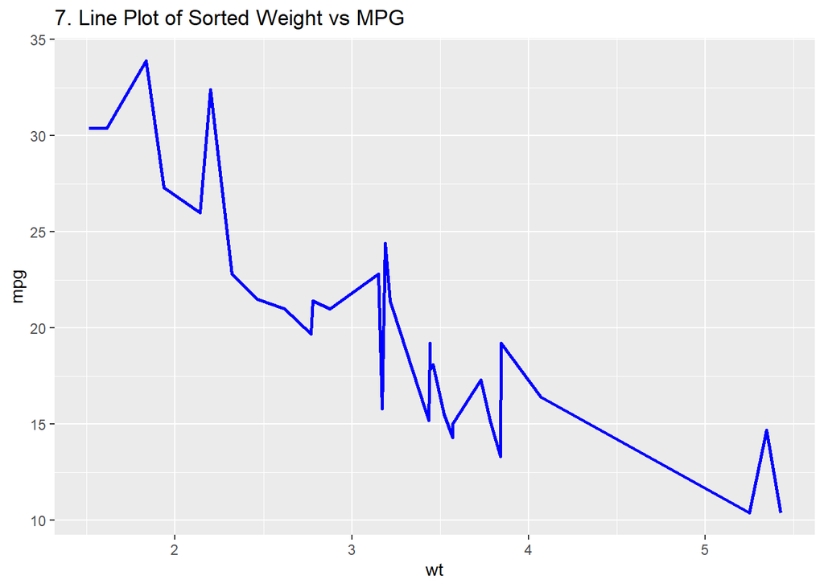

```r
ggplot(mtcars_sorted, aes(x = wt, y = mpg)) +
  geom_line(color = "blue", linewidth = 1) +
  labs(title = "7. Line Plot of Sorted Weight vs MPG")
```

# 9. Violin Plot (geom_violin) - Combines boxplot and density shape

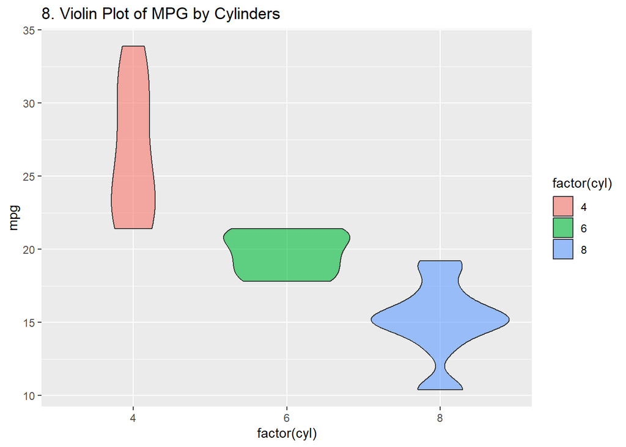

```r
ggplot(mtcars, aes(x = factor(cyl), y = mpg, fill = factor(cyl))) +
  geom_violin(alpha = 0.6) +
  labs(title = "8. Violin Plot of MPG by Cylinders")
```

# 10. Horizontal and Vertical Reference Lines (geom_hline & geom_vline)

These lines split the plot into quadrants based on the averages, making it easy to see which data points fall above or below the overall dataset means.

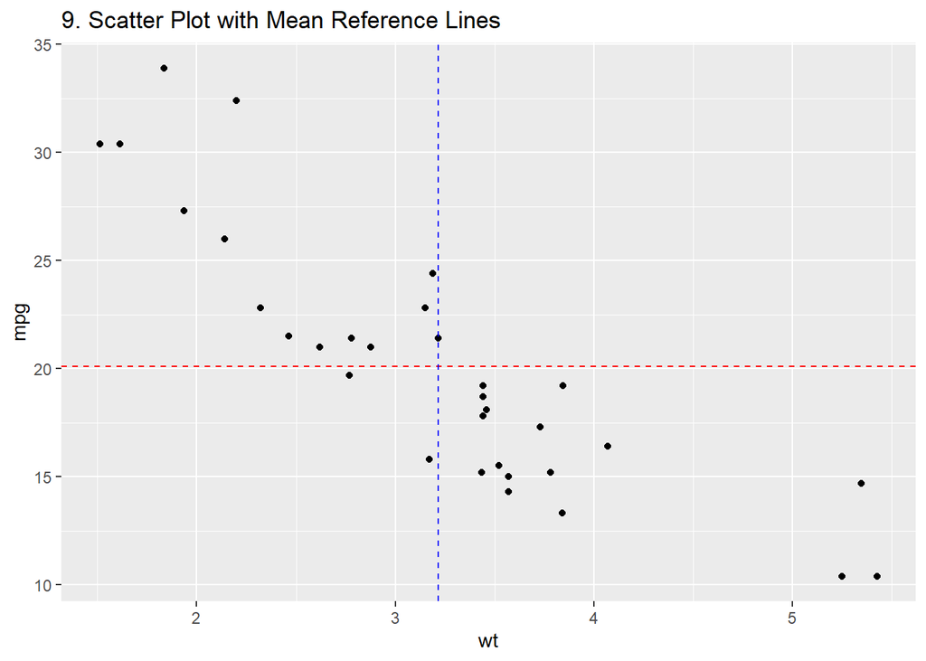

```r
ggplot(mtcars, aes(x = wt, y = mpg)) +
  geom_point(color = "black") +
  geom_hline(yintercept = mean(mtcars$mpg), color = "red", linetype = "dashed") +
  geom_vline(xintercept = mean(mtcars$wt), color = "blue", linetype = "dashed") +
  labs(title = "9. Scatter Plot with Mean Reference Lines")
```

#dashed red line representing the average MPG and a vertical dashed blue line representing the average weight.

# 11. Text Labels (geom_text) - Adds text directly onto data points

A scatter plot where each point is labeled with the name of the car.

It allows you to identify specific individual observations, making it easy to spot named outliers or extreme data points directly on the chart.

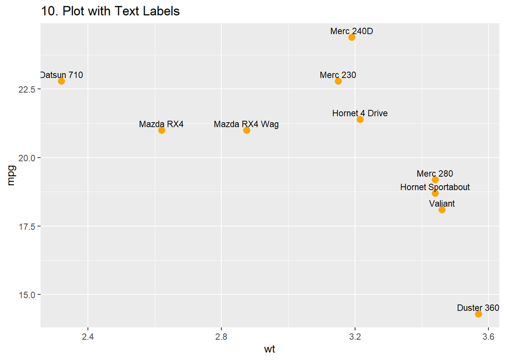

```r
mtcars_subset <- head(mtcars, 10) # just the first 10 rows for clarity
mtcars_subset$car_name <- rownames(mtcars_subset)
ggplot(mtcars_subset, aes(x = wt, y = mpg, label = car_name)) +
  geom_point(color = "orange", size = 3) +
  geom_text(vjust = -0.5, size = 3) +
  labs(title = "10. Plot with Text Labels")
```